# Coding Assignment 3

Team 5

Due: 2021-12-09 23:59

A Florida health insurance company wants to predict annual claims for individual clients. The company pulls a random sample of 50 customers. The owner wishes to charge an actuarially fair premium to ensure a normal rate of return. The owner collects all of their current customer’s health care expenses from the last year and compares them with what is known about each customer’s plan.

The data on the 50 customers in the sample is as follows:

- Charges: Total medical expenses for a particular insurance plan (in dollars)
- Age: Age of the primary beneficiary
- BMI: Primary beneficiary’s body mass index (kg/m2)
- Female: Primary beneficiary’s birth sex (0 = Male, 1 = Female)
- Children: Number of children covered by health insurance plan (includes other dependents as well)
- Smoker: Indicator if primary beneficiary is a smoker (0 = non-smoker, 1 = smoker)
- Cities: Dummy variables for each city with the default being Sanford

Answer the following questions using complete sentences and attach all output, plots, etc. within this report.

## Question 1

Randomly select three observations from the sample and exclude from all modeling (i.e. n=47). Provide the summary statistics (min, max, std, mean, median) of the quantitative variables for the 47 observations.

```r
set.seed(123457)
insuranceremove3 <- insurance[-sample(1:nrow(insurance), 3), ]
removequalitative1 <- insuranceremove3[,c('Charges','Age','BMI','Children')]
summary(removequalitative1)
```

```
##     Charges           Age             BMI           Children
##  Min.   : 1163   Min.   :18.00   Min.   :20.60   Min.   :0.000
##  1st Qu.: 5529   1st Qu.:28.50   1st Qu.:28.85   1st Qu.:0.000
##  Median : 9059   Median :42.00   Median :30.21   Median :1.000
##  Mean   :14243   Mean   :40.66   Mean   :32.09   Mean   :1.085
##  3rd Qu.:16100   3rd Qu.:52.00   3rd Qu.:34.41   3rd Qu.:2.000
##  Max.   :48970   Max.   :64.00   Max.   :53.13   Max.   :3.000
```

```r
sd(removequalitative1$Charges, na.rm = TRUE)
```

```
## [1] 13615.61
```

```r
sd(removequalitative1$Age, na.rm = TRUE)
```

```
## [1] 14.49329
```

```r
sd(removequalitative1$BMI, na.rm = TRUE)
```

```
## [1] 6.498423
```

```r
sd(removequalitative1$Children, na.rm = TRUE)
```

```
## [1] 1.176394
```

```r
index <- sample(seq_len(nrow(insuranceremove3)), size = 10)
train <- insuranceremove3[-index,]
test <- insuranceremove3[index,]
```

Three random observations were removed from the sample. The summary statistics for the quantitative variables are shown above. The standard deviations for Charges, Age, BMI, and Children are $13,615.61, 14.49329 years, 6.498423, and 1.176394 respectively.

## Question 2

Provide the correlation between all quantitative variables

```r
cor(removequalitative1)
```

```
##              Charges        Age         BMI    Children
## Charges   1.00000000 0.38965272  0.09188244 -0.03926254
## Age       0.38965272 1.00000000  0.09505474  0.14836527
## BMI       0.09188244 0.09505474  1.00000000 -0.19711293
## Children -0.03926254 0.14836527 -0.19711293  1.00000000
```

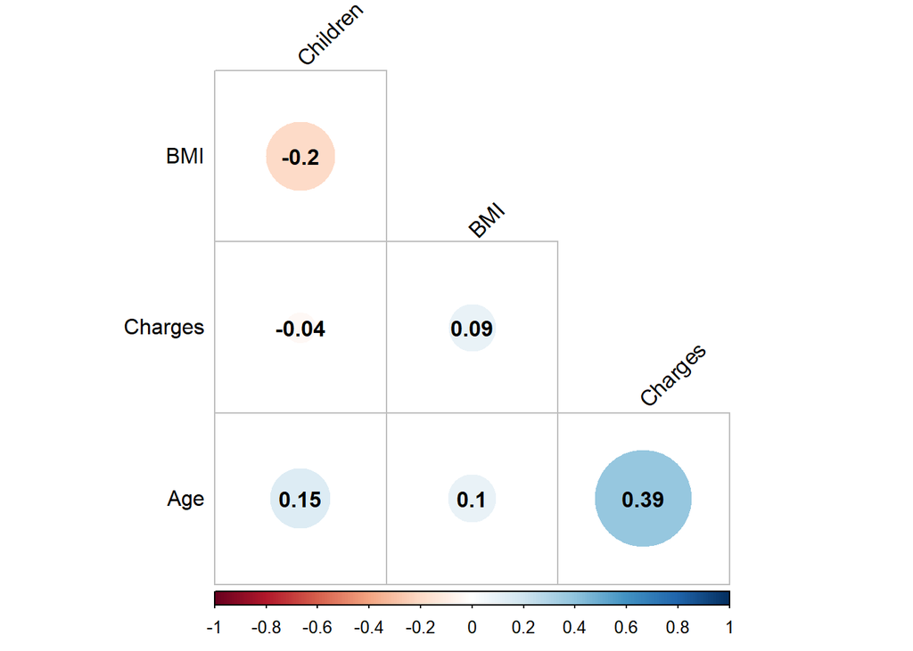

```r
corrplot(cor(removequalitative1),
type = "lower",
order = "hclust",
tl.col = "black",
tl.srt = 45,
addCoef.col = "black",
diag = FALSE)
```

The correlation between all of the the quantitative variables are displayed above. Age is shown to be the most positively correlated to Charges, with Children and BMI being the most negatively correlated to each other. Age and BMI, Charges and BMI, as well as Age and Children, are all slightly correlated. Charges and children have basically no correlation.

## Question 3

Run a regression that includes all independent variables in the data table. Does the model above violate any of the Gauss-Markov assumptions? If so, what are they and what is the solution for correcting?

```r
model <- lm(Charges~ Age + BMI + Female + Children + Smoker +WinterSprings + WinterPark + Oviedo, data = insuranceremove3)
summary(model)
```

```
##
## Call:
## lm(formula = Charges ~ Age + BMI + Female + Children + Smoker +
##     WinterSprings + WinterPark + Oviedo, data = insuranceremove3)
##
## Residuals:
##      Min       1Q   Median       3Q      Max
## -11506.1  -2013.3   -952.7   1378.7  24276.6
##
## Coefficients:
##               Estimate Std. Error t value Pr(>|t|)
## (Intercept)   -14379.9     7476.9  -1.923 0.061966 .
## Age              307.6       73.9   4.162 0.000174 ***
## BMI              273.1      177.4   1.540 0.131953
## Female          1613.0     1997.0   0.808 0.424287
## Children         640.6      901.8   0.710 0.481820
## Smoker         26000.1     2334.1  11.139 1.57e-13 ***
## WinterSprings   -723.9     3332.6  -0.217 0.829207
## WinterPark       246.8     3294.2   0.075 0.940660
## Oviedo          -590.1     3570.9  -0.165 0.869611
## ---
## Signif. codes:  0 '***' 0.001 '**' 0.01 '*' 0.05 '.' 0.1 ' ' 1
##
## Residual standard error: 6449 on 38 degrees of freedom
## Multiple R-squared:  0.8147, Adjusted R-squared:  0.7757
## F-statistic: 20.88 on 8 and 38 DF,  p-value: 1.06e-11
```

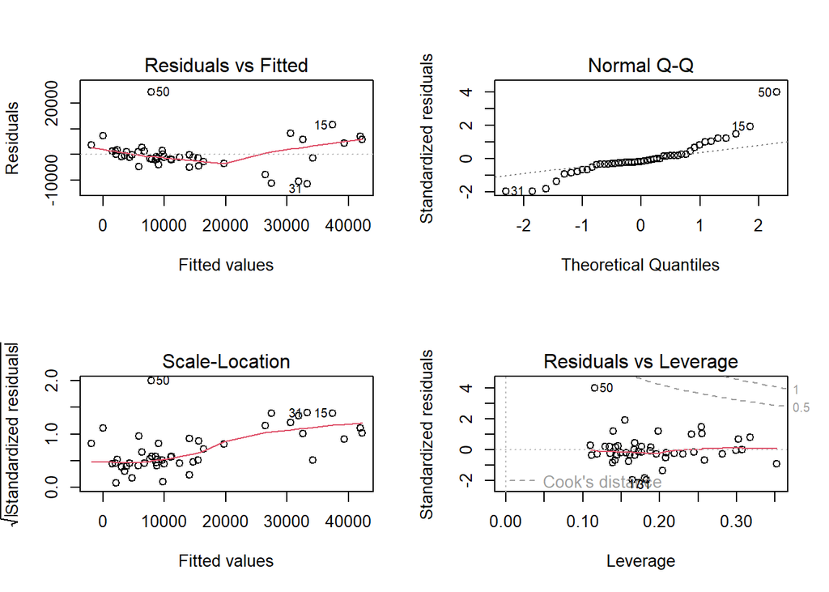

```r
par(mfrow=c(2,2))
plot(model)
```

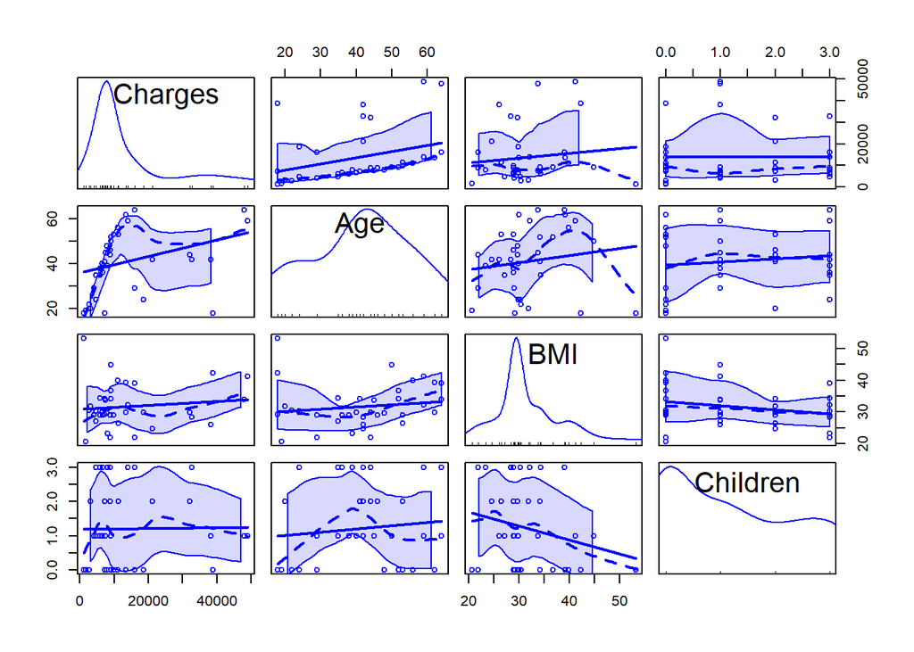

```r
scatterplotMatrix(train[,c(1:3,5)])
```

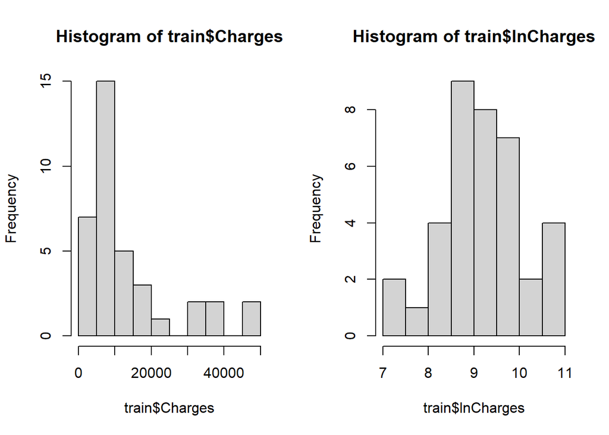

```r
par(mfrow=c(1,2))
hist(train$Charges) #before

train$lnCharges <- log(train$Charges)
hist(train$lnCharges) #after
```

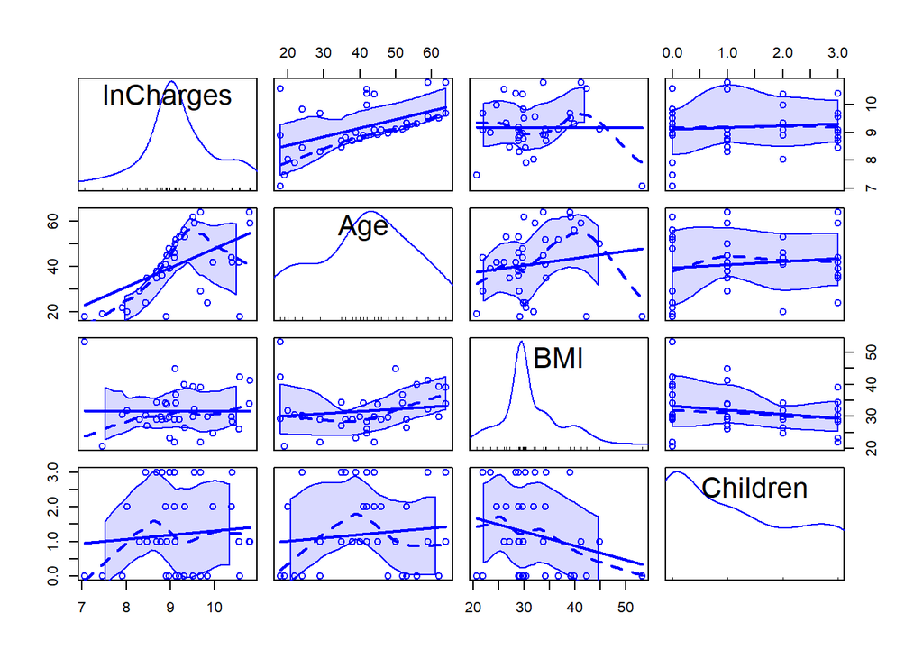

```r
scatterplotMatrix(train[,c(10,2,3,5)]) # grabbing lnCharges
```

The first plot above titled “Residuals vs. Fitted,” there is a non-linear relationship. This violates Gauss Markov assumption number 3. It is fixed by transforming the data.

The second plot above titled “Normal Q-Q,” shows the assumption of a normally distributed dependent variable for a fixed set of predictors. If this were a 45-degree line upwards, we could verify this. Unfortunately we do not have it in this case. This violates Gauss Markov assumption number 6. This is fixed by transforming the data.

The third plot “Scale-Location” is checking for homoskedasticity. This violates Gauss Markov assumption number 4. If this assumption were not violated, you’d see random points around a horizontal line. In this case, it is upward sloping, so you can see there is a “fanning out” effect. This is fixed by transforming the data.

## Question 4

Implement the solutions from question 3, such as data transformation, along with any other changes you wish. Use the sample data and run a new regression. How have the fit measures changed? How have the signs and significance of the coefficients changed?

```r
train$lnAge <- log(train$Age)
train$AgeSquared <- train$Age^2

#logarithmic relationship for Age
model2 <- lm(lnCharges ~., data = train[,c(10, 11, 2:9)] ) #pulling only columns I want
summary(model2)
```

```
##
## Call:
## lm(formula = lnCharges ~ ., data = train[, c(10, 11, 2:9)])
##
## Residuals:
##      Min       1Q   Median       3Q      Max
## -0.86631 -0.11397 -0.02372  0.05364  1.24134
##
## Coefficients:
##                Estimate Std. Error t value Pr(>|t|)
## (Intercept)    6.290139   4.204389   1.496    0.146
## lnAge          0.322209   1.528913   0.211    0.835
## Age            0.027159   0.042106   0.645    0.524
## BMI            0.005443   0.015985   0.340    0.736
## Female         0.138414   0.187801   0.737    0.467
## Children       0.051486   0.070384   0.731    0.471
## Smoker         1.500816   0.179345   8.368 5.59e-09 ***
## WinterSprings  0.166273   0.263654   0.631    0.534
## WinterPark    -0.074032   0.271689  -0.272    0.787
## Oviedo        -0.200951   0.289354  -0.694    0.493
## ---
## Signif. codes:  0 '***' 0.001 '**' 0.01 '*' 0.05 '.' 0.1 ' ' 1
##
## Residual standard error: 0.4356 on 27 degrees of freedom
## Multiple R-squared:  0.8115, Adjusted R-squared:  0.7486
## F-statistic: 12.91 on 9 and 27 DF,  p-value: 1.113e-07
```

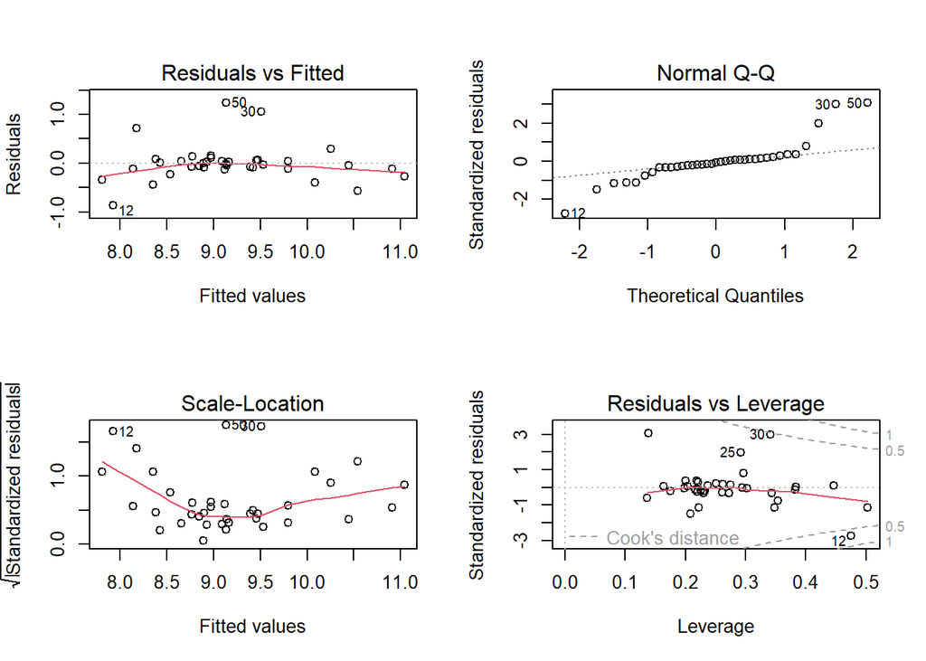

```r
par(mfrow=c(2,2))
plot(model2)
```

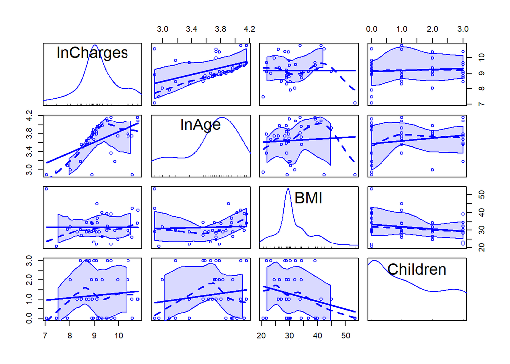

```r
scatterplotMatrix(train[,c(10,11,3,5)])
```

```r
#quadratic relationship for Age
model3 <- lm(lnCharges ~., data = train[,c(10,2:9,12)] ) #pulling only columns I want

summary(model3)
```

```
##
## Call:
## lm(formula = lnCharges ~ ., data = train[, c(10, 2:9, 12)])
##
## Residuals:
##      Min       1Q   Median       3Q      Max
## -0.84654 -0.12271 -0.03196  0.05467  1.22403
##
## Coefficients:
##                 Estimate Std. Error t value Pr(>|t|)
## (Intercept)    6.4451234  1.2279852   5.249 1.56e-05 ***
## Age            0.0652282  0.0449333   1.452    0.158
## BMI            0.0092073  0.0157957   0.583    0.565
## Female         0.1957129  0.1947036   1.005    0.324
## Children       0.0445169  0.0689858   0.645    0.524
## Smoker         1.5179209  0.1796629   8.449 4.63e-09 ***
## WinterSprings  0.1787638  0.2622710   0.682    0.501
## WinterPark    -0.0849194  0.2700630  -0.314    0.756
## Oviedo        -0.1947083  0.2872475  -0.678    0.504
## AgeSquared    -0.0003636  0.0005538  -0.657    0.517
## ---
## Signif. codes:  0 '***' 0.001 '**' 0.01 '*' 0.05 '.' 0.1 ' ' 1
##
## Residual standard error: 0.4326 on 27 degrees of freedom
## Multiple R-squared:  0.8141, Adjusted R-squared:  0.7522
## F-statistic: 13.14 on 9 and 27 DF,  p-value: 9.288e-08
```

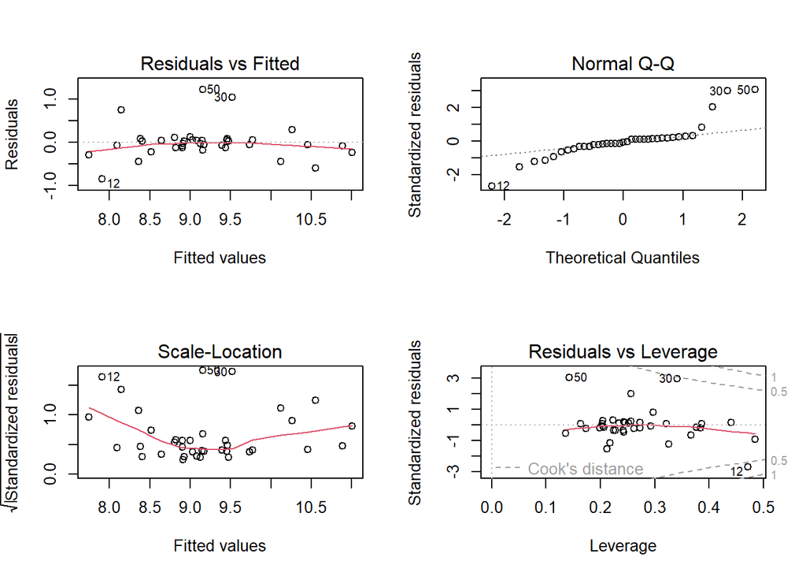

```r
par(mfrow=c(2,2))
plot(model3)
```

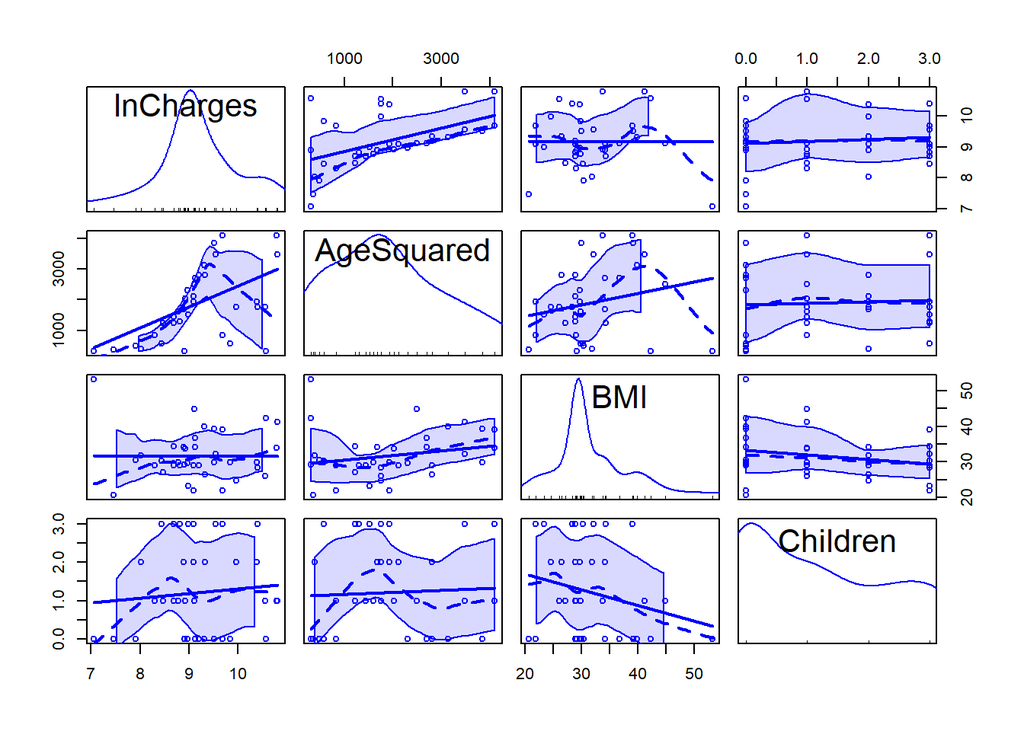

```r
scatterplotMatrix(train[,c(10,12,3,5)])
```